# The Prequel

## Getting ready

### Install R

Visit [The R Project](https://cran.r-project.org/) and select the appropriate “Download R” link for your operating system (Windows/Mac/Linux) from the top of the page.

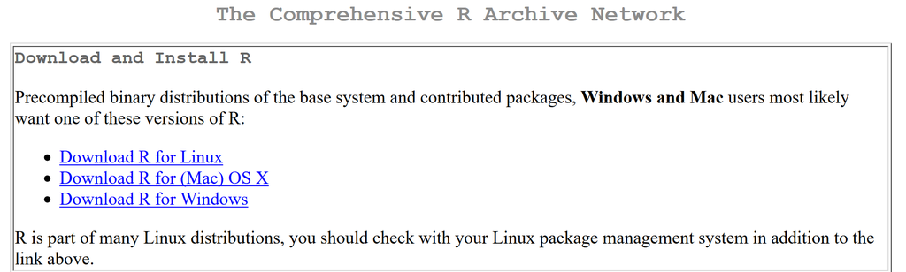

#### Mac

- After clicking “Download R for (Mac) OS X,” click on the file containing the latest version of R under “Files.”
- Save the .pkg file, double-click it to open, and follow the installation instructions.

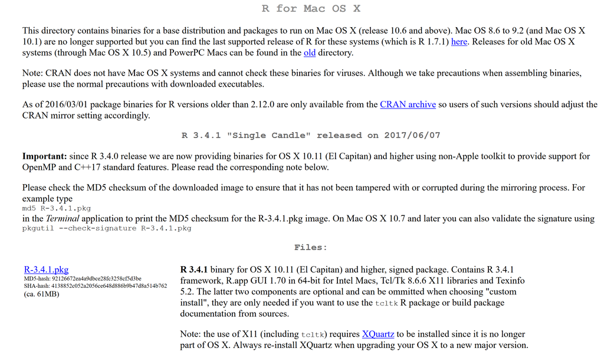

#### Windows

- After clicking “Download R for Windows,” click “base”

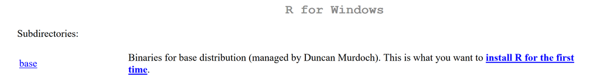

- Click “Download R 3.4.1 for Windows”

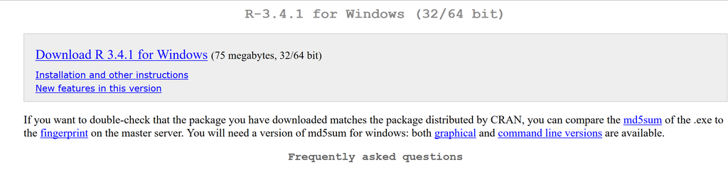

- Save the executable file somewhere on your computer. Run the .exe file and follow the installation instructions.

### Install RStudio

Visit [RStudio](http://www.rstudio.com/products/rstudio/download/), select RStudio Desktop (Open Source License) - FREE on the left.

[figure not shown]

- Click the link appropriate to your system (Windows or Mac)

#### Mac

Save the .dmg file on your computer, double-click it to open, and then drag and drop it to your applications folder.

#### Windows

Save the executable file. Run the .exe file and follow the installation instructions.